# LRR des poissons d’eau douce de BFC

20_pre_traitements_donnees_ope_especes

PabloVigneron

2026-04-30

# 1 Objectif : Dynamique de population des poissons d’eau douce de Bretagne

Script : 20_pre_traitements_donnees_ope_especes

Il s’agit de réaliser une étape de pré-traitements et de mise en qualité des données sur la sélection des opérations réalisée précedemment. Il s’agit également de réaliser une mise en qualité des données individuelles des espèces propres à chacune des opérations. Il s’agit notamment d’observer les valeurs aberrantes contenues dans les mesures individuelles des poissons (mesures de tailles / poids / …).

# 2 Installation

## 2.1 Paramètres

Des paramètres sont fixés et sont modifiables selon les préférences et les objectifs visés. Parmi ces paramètres :

- Sélection des passages de pêche à retirer : dans notre étude, les passages “2” et “3” sont retirés par soucis d’homogénéité entre les différents protocoles de pêches. Seuls les passages “0” et “1” sont conservés. Ces derniers correspondent au premier ou à l’unique passage réalisé lors d’une opération de pêche.

## 2.2 Chargement des packages et des données

```r
library(aspe)
#install.packages("C:/Users/pablo.vigneron/Downloads/PascalIrz-aspeQual-643d282.tar.gz", repos = NULL, type = "source")
#devtools::install_github("PascalIrz/aspeQual") # Instalation du package 'aspeQual'
library(aspeQual)
library(tidyverse)
library(readxl)
library(DT)
```

```r
load(file = "../processed_data/selection_especes.rda")
load(file = "../processed_data/selection_pop_ope.rda")
```

```r
rdata_tables <- misc_nom_dernier_fichier(
  repertoire = "../../../../Liste_rouge_BFC/raw_data",
  pattern = "^tables")
load(rdata_tables) # Chargement des données

mei_table <- misc_nom_dernier_fichier(
  repertoire = "../../../../Liste_rouge_BFC/raw_data",
  pattern = "^mei")
load(mei_table) # Chargement des données
```

```r
## Lire le fichier Excel contenant les classes de maturité des espèces
traits_biologiques <- read_excel("../raw_data/traits_biologiques.xlsx")
```

```r
source(file = "../R/detecter_erreurs_tailles.R")
source(file = "../R/classe_couleur_erreur.R")
```

# 3 Constitution du jeu de données

Dans cette étude, nous souhaitons distinguer les individus “adultes” des individus “juvéniles”. Pour cela, nous devons réaliser une “classe de taille” de référence permettant, à partir de la taille des poissons pêchés lors des opérations, de séparer les poissons “adultes” des “juvéniles”. Ce choix est réalisé en raisonnance avec la méthodologie de la liste rouge qui incite à n’évaluer que les individus matures dans les analyses si les données le permettent (UICN France, 2018).

## 3.1 Selection des tailles de maturité des espèces

En complément de la base *aspe*, un tableau indiquant pour chaque espèce la taille maximale des 0+ est constitué (= taille référence minimum adulte). La longueur du poisson est utilisée comme proxy de son âge. Les tailles de maturité de *référence* sont renseignées à partir de 5 sources différentes pour chacune des espèces, et rassemblées dans un fichier Excel à importer sur R.

### 3.1.1 Construction du fichier Excel “traits_biologiques”

- 1ere colonne : “espece_presence_lrr_2015” : la valeur 1 est inscrite si l’espèce a été présente sur la précédente lrr ; la valeur 0 est inscrite dans le cas contraire.
- 2ème colonne : “esp_nom_commun” : nom commun de l’espèce.
- 3ème colonne : “esp_code_alternatif” : code à 3 lettres de l’espèce.
- n colonne(s) : valeurs de taille référence minimum adulte issue de la documentation.
- n+1 colonne : “taille_maturite_ref” : valeur médiane des différentes tailles issues de la documentation*.
- Dans le cas de cette étude - 5 colonnes issues de différentes sources : 1 et 2 : Ouvrages d’identification des poissons d’eau douce de France (Keith *et al.*, 2020 ; Derouch, 2024); 3 : Observation des courbes de tailles dans le fichier R “estimation_taille_0+” à partir des données de taille de la base *aspe*; 4 : Valeurs de *fishbase* ; 5 : Valeurs de référence des espèces d’Occitanie.

  Les différentes tailles de référence sont donc regroupées dans le tableau *traits_biologiques* et pour chacune des espèces, la médiane de l’ensemble des valeurs recueillies a été retenue pour être inscrite comme la valeur de référence de maturité.

```r
traits_biologiques <- traits_biologiques %>% # Construction d'un jeu de données contenant les tailles de maturité
  select(esp_code_alternatif, taille_maturite_ref)
```

## 3.2 Création d’un jeu de données des mesures individuelles

Il s’agit maintenant de créer un dataframe contenant l’ensemble des données individuelles relatives aux espèces sélectionnées ainsi qu’aux opérations de pêches contenues dans la passerelle (cf script 00_selection_pop_ope et 03_analyse_selection_especes). La taille des poissons est indiquée en millimètre et le poids en gramme. Dans ce nouveau jeu de données *mei_ope_selection*, nous ne retenons que les données en lien avec le dataframe *esp_ope_selection* (espèces sélectionnées lors du dernier script).

```r
# mei_for_join <- temp_df %>%
#   rename(lop_id = mei_lop_id)
```

```r
mesure_individuelle <- temp_df # renommer temp_df en mesure_individuelle pour pouvoir utiliser correctement les fonctions du package Aspe
```

```r
mei_ope_selection <- passerelle %>%
  mef_ajouter_ope_date() %>%
  # left_join(y = mei_for_join) %>%
  # left_join(mei_for_join , by = "lop_id") %>% #ajouter les mei manuellement
  mef_ajouter_mei() %>%
  mef_ajouter_lots() %>%
  mef_ajouter_type_protocole() %>%
  mef_ajouter_passage() %>% # Ajout des passages de pêches
  mef_ajouter_type_lot() %>%
  mef_ajouter_type_longueur() %>%
  select(
    ope_id,
    lop_id,
    lop_effectif,
    esp_code_alternatif,
    mei_id,
    sta_id,
    pop_id,
    mei_taille,
    pas_numero,
    tyl_libelle,
    pro_libelle,
    annee,
    tlo_libelle
  )
```

# 4 Modif provisoire : Pour le df final script GLMM et GAMMS

Attention **lop_effectif** correspond à l’effectis totale du lots !! Prenons l’exemple d’un lot de 4 CHA, on retrouvera 4 lignes avec chacune la valeur de 4 pour l’effectif. Pour le df finale, il faut que chaque effectif correspondent à 1 seul effectif par ligne !!!

```r
# mei_ope_selection_test <- mei_ope_selection %>%
#   mutate(lop_effectif_r = if_else(lop_effectif >= 1, 1, 0))
```

Nous retirons les passages supérieurs à 1 qui ne seront pas étudiés par soucis d’homogénéité des données (cf Paramètres). Nous ne considérons que les espèces sélectionnées suite au script 03_selection_especes (contenues dans l’objet *mes_especes*).

```r
mei_ope_selection <- mei_ope_selection %>%
  mutate(pas_numero = replace_na(pas_numero,0)) %>% # Passages "NA" transformés en "0" (équivalent)
  filter(!pas_numero %in% params$passage_a_retirer,
         esp_code_alternatif %in% mes_especes) %>% # Passages "2" et "3" sont retirés
  distinct()
```

## 4.1 Données manquantes

Certaines valeurs absentes / manquantes (“NA”) peuvent être observées au sein du jeu de données constitué. Celles-ci peuvent être dûes à des problèmes de retranscription dans la base de données *aspe*. Les lignes contenant des valeurs manquantes sont regroupées dans un dataframe *valeur_na*.

```r
valeur_na <- mei_ope_selection %>% # Isolement des lignes contenant des NA dans un dataframe
  filter(if_any(everything(), is.na))

mei_ope_selection <- na.omit(mei_ope_selection)
```

La taille médiane des espèces à l’échelle de leur station est calculée dans le jeu de données *esp_taille_med_sta*. Ces valeurs sont ensuite assignées comme valeurs de références en cas de valeurs manquantes (à la station).

```r
esp_taille_na_med_sta <- mei_ope_selection %>% # Dataframe contenant les tailles médiannes des espèces par station
  group_by(sta_id,
           esp_code_alternatif) %>%
  summarise(mei_taille_med = median(mei_taille, na.rm = TRUE)) %>%
  ungroup()
```

```r
summary(esp_taille_na_med_sta)
```

```
##      sta_id        esp_code_alternatif mei_taille_med
##  Min.   :   2422   Length:2396         Min.   : 20.0
##  1st Qu.:   8843   Class :character    1st Qu.: 64.0
##  Median :  19140   Mode  :character    Median : 91.0
##  Mean   :  58115                       Mean   :134.8
##  3rd Qu.:  19791                       3rd Qu.:144.0
##  Max.   :4331694                       Max.   :960.0
```

```r
valeur_na_complet <- valeur_na %>% # Remplacement valeurs de tailles manquantes par les valeurs du dataframe esp_taille_na_med_sta
  left_join(esp_taille_na_med_sta, by = c("sta_id", "esp_code_alternatif")) %>%
  mutate(mei_taille = coalesce(mei_taille, mei_taille_med)) %>%
  select(-mei_taille_med)
```

Le jeu de données initial *mei_ope_selection* est ensuite complété des lignes précèdemment retirées (les valeurs de tailles manquantes sont remplacées par les données de tailles médianes des espèces à l’échelle de la station).

```r
mei_ope_selection <- bind_rows(mei_ope_selection, valeur_na_complet)
```

## 4.2 Distinction des classes d’âges

Une distinction des classes d’âges est réalisée sur le jeu de données *mei_ope_selection* : à chaque espèce correspond alors 3 stades différents : - “ad”: individu adulte dont la taille est supérieure à la *taille_maturite_ref* spécifique à l’espèce ; - “juv”: individu juvénile dont la taille est inférieure à la *taille_maturité_ref* spécifique à l’espèce ; - “ind”: Indifférencié = toutes classes d’âges confondues (ad + juv).

```r
mei_ope_selection <- mei_ope_selection %>%
  left_join(traits_biologiques)

mei_ope_selection <- mei_ope_selection %>%
  mutate(stade = ifelse(mei_ope_selection$mei_taille < mei_ope_selection$taille_maturite_ref,
                         "juv","ad")) # Ajout du stade pour chacune des lignes de mei_ope_selection
```

# 5 Relation tailles / poids

La mise en place des relations tailles / poids est réalisée grâce au package *apse* et au tutoriel *Construire des relations taille- poids*, réalisé par **Mr Pascal Irz** (https://rpubs.com/kamoke/729779). Cette relation nous permet de relier la longueur d’un poisson à son poids. Les mesures de poids sont rarement prises lors des pêches mais son pourtant nécessaires dans le calcul d’indicateurs simples comme pour les biomasses. Ainsi, nous utilisons cette relation afin d’obtenir des valeurs de poids indicatives remplaçant les valeurs *NA* de poids dans notre jeu de données *mei_ope_selection*. Elles seront alors remplacées par des estimations de poids en fonction de la taille du poissons : *poids_tp*.

```r
mei_taille_poids <- aspe::data_taille_poids %>% # Utilisation des relations taille - poids du package aspe
  group_by(esp_code_alternatif,
           tlo_libelle) %>%
  arrange(source) %>%
  slice(1)
```

```r
# nb : vérifier qu'on a bien les tailles pour tous les poissons avant d'appliquer la taille-poids
# combinaisons espèces - type de longueur absentes de la table de conversion

mei_tp_manquantes <- mei_ope_selection %>%
  select(esp_code_alternatif,
         tlo_libelle) %>%
  distinct() %>%
  left_join(y = mei_taille_poids) %>%
  filter(is.na(a))

# nb : certaines espèces n'ont pas de relation en longueur fourche, on approxime par la longueur totale

mei_esp_tp_manquantes <- mei_tp_manquantes %>%
  pull(esp_code_alternatif)
```

#Modif temporaire des NA pour tester le code !!!!

```r
# mei_ope_selection <- mei_ope_selection %>%
#   filter(!esp_code_alternatif %in% c("SPI", "VAI", "ABL", "BOU", "CHA", "ASP"))
```

```r
mei_ope_selection <- mei_ope_selection %>%
  mutate(tlo_libelle = ifelse(
      esp_code_alternatif %in% mei_esp_tp_manquantes &
        tlo_libelle == "Fourche", "Totale",
      tlo_libelle
    ))
```

On ajoute les *poids_tp* dans notre jeu de données *mei_ope_selection* :

```r
mei_ope_selection <- mei_ope_selection %>%
  left_join(y = mei_taille_poids,
            by = c("esp_code_alternatif", "tlo_libelle")) %>%
  mutate(poids_tp = a * ((mei_taille / 10) ^ b)) # On ajoute les poids_tp
```

# 6 Qualité des données individuelles (tailles / poids)

Maintenant que nous avons toutes les données regroupées dans un dataframe général (*mei_ope_selection*), nous pouvons passer au traitement qualitatif des données individuelles des poissons et notamment des valeurs poids et de tailles.

## 6.1 Vérification des poids estimés

En ajoutant les valeurs de poids mesurés (*mei_poids*), nous pouvons les comparer aux poids estimés par la relation (*poids_tp*). Il s’agit de regarder les différences entre les poids réels et les poids estimés.

```r
mei_ope_selection <- mei_ope_selection %>% # Ajout des mesures de poids existantes
  # left_join(y = mei_for_join ) %>% #ajouter les mei manuellement
   mef_ajouter_mei() %>% #Ajout des données individuelles de poids
  select(ope_id:poids_tp, mei_poids)
```

```r
mei_ope_selection_poids <- mei_ope_selection %>%
  filter(!is.na(mei_poids)) # Filtrer les données pour enlever les NA dans la colonne mei_poids
```

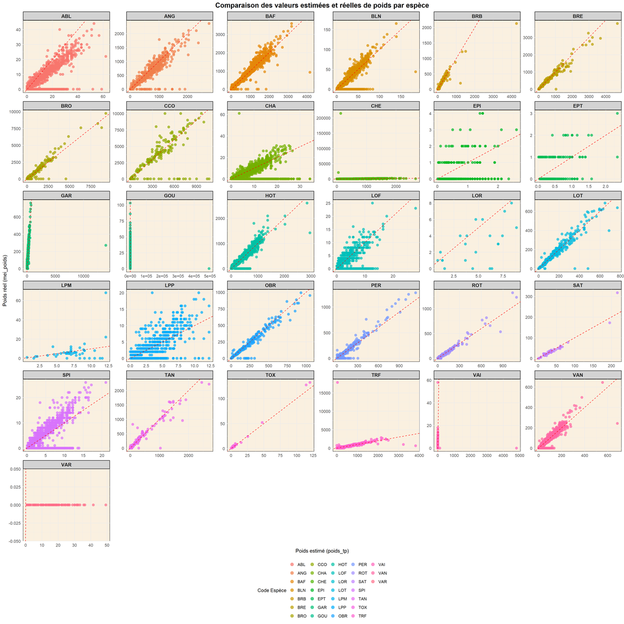

```r
ggplot(mei_ope_selection_poids, aes(x = poids_tp, y = mei_poids, color = esp_code_alternatif)) +
  geom_point(alpha = 0.7, size = 3) +
  geom_abline(slope = 1, intercept = 0, linetype = "dashed", color = "red") +
  facet_wrap(~ esp_code_alternatif, scales = "free", labeller = label_wrap_gen(width = 8)) +
  labs(title = "Comparaison des valeurs estimées et réelles de poids par espèce",
    x = "Poids estimé (poids_tp)",
    y = "Poids réel (mei_poids)",
    color = "Code Espèce") +
  theme_minimal(base_size = 15) +
  theme(panel.background = element_rect(fill = "#faf0e0"),
    plot.title = element_text(hjust = 0.5, size = 20, face = "bold"),
    plot.subtitle = element_text(hjust = 0.5, size = 16),
    legend.position = "bottom",
    legend.title = element_text(size = 14),
    legend.text = element_text(size = 12),
    strip.background = element_rect(fill = "lightgrey", color = "black", size = 1),
    strip.text = element_text(size = 14, face = "bold")
  ) + guides(color = guide_legend(override.aes = list(size = 4)))
```

Nous observons que beaucoup de valeurs “0” sont présentes dans les valeurs de poids réelles. Il s’agit très probablement de valeurs “NA” inscrites en 0. Ces dernières sont à corriger dans la base ASPE.

## 6.2 Vérification des tailles

### 6.2.1 Mise en place de seuils de détection d’erreurs de tailles

Il s’agit de mettre en place des seuils pour détecter des erreurs potentielles dans les tailles de poissons. Il s’agit donc d’instaurer des valeurs de tailles “minimum” et “maximum” pour chaque espèce. Pour cela, nous crééons un jeu de données ne contenant que les lignes ayant fait l’objet de mesures sur la longueur totale du poisson :

```r
esp_lt_data <- mei_ope_selection %>%
  ungroup() %>%
  filter(tlo_libelle == "Totale",
         esp_code_alternatif == esp_code_alternatif)
```

La fonction *qtp_seuils* permet d’isoler les tailles minimum et maximum des différentes espèces au sein du jeu de données *esp_lt_data*. Cette fonction est tirée du packages *aspeQual* dédié à la mise en qualité de la base *aspe* réalisé par Mr Pascal Irz.

```r
mei_df_seuils <- aspeQual::qtp_seuils(df = esp_lt_data,
                                      var_taxon = esp_code_alternatif,
                                      var_a_tester = mei_taille,
                                      seuil_densite = 0.001)
```

```r
mei_ope_selection <- mei_ope_selection %>% # Joindre les seuils calculés avec le jeu de données principal
  left_join(mei_df_seuils, by = "esp_code_alternatif")
```

## 6.3 Détection des erreurs de tailles

La fonction *detecter_erreurs_tailles* est créée afin de recenser les valeurs de tailles abérantes contenues dans un dataframe. Elle est appliquée sur notre jeu de données *mei_ope_selection*. *erreur_df* est le jeu de données dans lequel l’ensemble des données de tailles supérieures ou inférieures aux seuils calculés précédemment sont stockées. Il est nécessaire de corriger ces éventuelles erreurs de saisies ou d’unités directement dans la base *aspe*.

```r
erreurs_df <- detecter_erreurs_tailles(df = mei_ope_selection)
```

```
##     ope_id esp_code_alternatif   mei_id mini maxi mei_taille
## 1    36700                 GOU  6201034   13  173        444
## 2    36821                 VAI  6198627   11   98        105
## 3    36612                 VAI  6465676   11   98        100
## 4    37308                 GOU  6466009   13  173        176
## 5    37308                 GOU  6466010   13  173        175
## 6    37228                 GOU  6199519   13  173         11
## 7    36323                 GOU  6316115   13  173         10
## 8    37215                 BLN  6427008   18  235         17
## 9    37215                 BLN  6427007   18  235         17
## 10   35881                 VAI  6352432   11   98        104
## 11   35881                 VAI  6352420   11   98        101
## 12   37498                 VAI  6510554   11   98         99
## 13   38012                 SPI  6582505   17  135         14
## 14   37023                 VAI  6204129   11   98        222
```

[output cut: 416 more lines]

Nous affichons, par ordre de priorité, les erreurs les plus abérrantes contenues dans le jeu de données *erreurs_df*. Nous fixons l’ordre d’abérration des données à travers les variables var_rouge / var_darkorange / var_orange, contenues dans la fonction *classe_couleur_erreur*.

```r
erreurs_df <- erreurs_df %>%
  rowwise() %>%
  mutate(color = classe_couleur_erreur(var_taille = mei_taille,
                                valeur_mini = mini,
                                valeur_maxi = maxi,
                                var_rouge = 150, # Rouge lorsque la taille réelle dépasse 150mm de la taille indiquée comme maximum
                                var_darkorange = 75,
                                var_orange = 25)) %>%
  ungroup() %>%
  mutate(severity = case_when(
    color == "red" ~ 1,
    color == "darkorange" ~ 2,
    color == "orange" ~ 3,
    TRUE ~ 4)) %>%  # Pour s'assurer qu'il y a une valeur de gravité pour chaque ligne
  arrange(severity)
```

Le tableau d’erreurs peut être affiché, avec en couleur, les ordres de priorités de correction des erreurs (allant de blanc à rouge).

```r
datatable(erreurs_df %>% select(-severity), options = list(pageLength = 25)) %>%
  formatStyle('color',
    columns = c("ope_id", "esp_code_alternatif", "mei_id", "mini", "maxi", "mei_taille"),
    target = 'row',
    backgroundColor = styleEqual(
      c("red", "darkorange", "orange"),
      c("red", "darkorange", "orange")))
```

|  | ope_id | esp_code_alternatif | mei_id | mini | maxi | mei_taille | color |
| --- | --- | --- | --- | --- | --- | --- | --- |
| 1 | 36700 | GOU | 6201034 | 13 | 173 | 444 | red |
| 2 | 36713 | VAI | 6358050 | 11 | 98 | 4058 | red |
| 3 | 37998 | VAI | 6533318 | 11 | 98 | 741 | red |
| 4 | 37998 | VAI | 10826544 | 11 | 98 | 356 | red |
| 5 | 37998 | VAI | 10826545 | 11 | 98 | 263 | red |
| 6 | 37998 | VAI | 10826553 | 11 | 98 | 361 | red |
| 7 | 37998 | VAI | 10826570 | 11 | 98 | 286 | red |
| 8 | 37998 | VAI | 10826586 | 11 | 98 | 451 | red |
| 9 | 37998 | VAI | 10826590 | 11 | 98 | 316 | red |
| 10 | 37998 | VAI | 10826604 | 11 | 98 | 252 | red |

[output cut: 420 more lines]

# 7 Qualité des données de lots (lop_id / lop_effectif)

## 7.1 Vérification *lop_id*

Dans le jeu de données *mei_ope_selection*, on s’attend à avoir autant de ligne **lop_id** (identifiants de lots) que de ligne **lop_effectif** (effectifs des lots). Il peut cependant y avoir des exceptions, notamment lorsque la nature du lot est “S/M” et a une valeur d’effectif de 30.

```r
verif_effectif <- mei_ope_selection %>%
  group_by(esp_code_alternatif,
           lop_id,
           lop_effectif
           ) %>%
  summarise(nbr_lignes = n()) %>%
  ungroup()

resultat_verif_effectif <- verif_effectif %>%
  filter(nbr_lignes!= lop_effectif)
```

Lorsque le nombre de ligne est supérieur au *lop_effectif*, il s’agit d’erreur de retranscription. On remplace alors la valeur de *lop_effectif* par le nombre de ligne contenu dans la colonne “nbr_lignes”.

```r
mei_ope_selection <- mei_ope_selection %>%
  left_join(verif_effectif, by = c("esp_code_alternatif", "lop_id", "lop_effectif")) %>%
  mutate(lop_effectif = ifelse(lop_effectif < nbr_lignes, nbr_lignes, lop_effectif)) %>%
  select(-nbr_lignes)
```

## 7.2 Vérification *mei_id*

Dans ce même jeu de données, il doit normalement n’y avoir qu’un *mei_id* par ligne (et pas de doublons) : ainsi, *nb_unique* doit théoriquement être égal au nombre total de lignes de *mei_ope_selection* (nous devons cependant y soustraire les *mei_id* ayant des valeurs NA (cas anormaux venant de la base ASPE - à corriger - mais sans conséquence pour la suite de l’analyse)).

```r
nb_unique <- mei_ope_selection %>% # Calcul du nombre unique de mei_id
  summarise(nb_unique = n_distinct(mei_id, na.rm = TRUE)) %>%
  pull()

nb_na <- mei_ope_selection %>%
  summarise(nb_na = sum(is.na(mei_id))) %>%
  pull(nb_na)

nb_lignes <- mei_ope_selection %>%
  nrow() # Nombre de lignes dans mei_ope_selection
```

```r
# Comparaison et affichage du message
if (nb_unique + nb_na == nb_lignes) {
  print("Le nombre de valeurs uniques de mei_id est égal au nombre de lignes de mei_ope_selection.")
} else {
  print("Le nombre de valeurs uniques de mei_id n'est pas égal au nombre de lignes de mei_ope_selection.")}
```

```
## [1] "Le nombre de valeurs uniques de mei_id est égal au nombre de lignes de mei_ope_selection."
```

```r
mei_ope_selection <- mei_ope_selection %>% # Convertir mei_id en chaîne de caractères
  mutate(mei_id = as.character(mei_id))

# Création d'un vecteur de noms pour remplacer les NA
na_vigilance <- paste0("na_vigilance_", seq_along(which(is.na(mei_ope_selection$mei_id))))

mei_ope_selection <- mei_ope_selection %>% # Remplacement des NA dans mei_id par les valeurs de na_vigilance
  mutate(mei_id = replace(mei_id, is.na(mei_id), na_vigilance))
```

```r
mei_ope_selection <- mei_ope_selection %>%
  mutate(stade = as.factor(stade))
summary(mei_ope_selection)
```

```
##      ope_id          lop_id         lop_effectif    esp_code_alternatif
##  Min.   :11207   Min.   :1504948   Min.   :   1.0   Length:1090847
##  1st Qu.:37427   1st Qu.:4304354   1st Qu.:  28.0   Class :character
##  Median :38424   Median :4411157   Median : 105.0   Mode  :character
##  Mean   :59141   Mean   :4770328   Mean   : 284.2
##  3rd Qu.:87985   3rd Qu.:5486866   3rd Qu.: 312.0
##  Max.   :96052   Max.   :6076699   Max.   :3511.0
##
##     mei_id              sta_id            pop_id           mei_taille
##  Length:1090847     Min.   :   2422   Min.   :    9872   Min.   :   1.00
##  Class :character   1st Qu.:   8843   1st Qu.:   33328   1st Qu.:  47.00
##  Mode  :character   Median :  18976   Median :   67711   Median :  63.00
##                     Mean   :  77545   Mean   :  268399   Mean   :  76.61
##                     3rd Qu.:  19639   3rd Qu.:   69335   3rd Qu.:  86.00
##                     Max.   :4331694   Max.   :14895981   Max.   :4100.00
##
##    pas_numero     tyl_libelle        pro_libelle            annee
##  Min.   :0.0000   Length:1090847     Length:1090847     Min.   :2007
##  1st Qu.:0.0000   Class :character   Class :character   1st Qu.:2013
##  Median :0.0000   Mode  :character   Mode  :character   Median :2017
##  Mean   :0.3982                                         Mean   :2017
##  3rd Qu.:1.0000                                         3rd Qu.:2022
##  Max.   :1.0000                                         Max.   :2025
##
##  tlo_libelle        taille_maturite_ref  stade        esp_nom_latin
##  Length:1090847     Min.   : 34.0       ad  :238872   Length:1090847
##  Class :character   1st Qu.: 70.0       juv :780425   Class :character
##  Mode  :character   Median :100.0       NA's: 71550   Mode  :character
##                     Mean   :110.8
##                     3rd Qu.:100.0
##                     Max.   :750.0
##                     NA's   :71550
##        a                  b            source             n_etudes
##  Min.   :0.001088   Min.   :2.476   Length:1090847     Min.   : 1.000
##  1st Qu.:0.007115   1st Qu.:2.985   Class :character   1st Qu.: 1.000
##  Median :0.009881   Median :3.042   Mode  :character   Median : 1.000
##  Mean   :0.011561   Mean   :3.010                      Mean   : 5.169
##  3rd Qu.:0.011165   3rd Qu.:3.080                      3rd Qu.: 8.000
##  Max.   :0.045763   Max.   :3.383                      Max.   :54.000
##
##     poids_tp           mei_poids              mini         maxi
##  Min.   :     0.00   Min.   :     0.00   Min.   : 3   Min.   :  71.0
##  1st Qu.:     1.05   1st Qu.:     0.00   1st Qu.: 7   1st Qu.:  98.0
##  Median :     2.58   Median :     0.00   Median :11   Median : 170.0
##  Mean   :    19.45   Mean   :    62.28   Mean   :11   Mean   : 233.9
##  3rd Qu.:     6.34   3rd Qu.:    24.00   3rd Qu.:14   3rd Qu.: 333.0
##  Max.   :847840.16   Max.   :215142.00   Max.   :60   Max.   :1150.0
##                      NA's   :955872
```

# 8 Sauvegarde

Nous sauvegardons dans un fichier .rda le jeu de données *mei_ope_selection* qui nous servira pour des analyses futures.

```r
save(mei_ope_selection,
     file = "../processed_data/pre_traitements_donnees_especes.rda")
```

# 9 Références bibliographiques

Derouch, M. (2024). Cahier d’identification des Poissons d’eau douce de France. Mèze : Biotope éditions, 128 p.

Keith, P., Poulet, N., Denys, G., Changeux, T., Feunteun, É., Persat, H. (2020). Les poissons d’eau douce de France. Deuxième édition. Muséum national d’Histoire naturelle, Paris ; Biotope, Mèze, 704 p. (Inventaires & biodiversité ; 18).

Irz, P. (2023). aspeQual: quality control over the aspe database. R package version 1.0.0, https://github.com/PascalIrz/aspeQual/

Irz, P., Mondy, C., Richard, B. Bonnafoux, L. (2024). aspe: An R package to analyse and visualise river fish data in France. R package version 0.4.1, https://github.com/PascalIrz/aspe/

UICN France (2018). Guide pratique pour la réalisation de Listes rouges régionales des espèces menacées - Méthodologie de l’UICN & démarche d’élaboration. Seconde édition. Paris, France.